# 1 - Exploratory Data Analysis

## 1.1 Univariate Analysis

```python
# Import all needed libraries
import numpy as np
import pandas as pd
import matplotlib.pyplot as plt
import seaborn as sns
%matplotlib inline
from IPython.core.interactiveshell import InteractiveShell
InteractiveShell.ast_node_interactivity='all'
from sklearn.model_selection import train_test_split
from sklearn.tree import DecisionTreeClassifier
from sklearn.metrics import accuracy_score, f1_score, recall_score, precision_score, confusion_matrix
import warnings
warnings.filterwarnings("ignore")
```

```python
# Load Data
df = pd.read_csv('concrete.csv')
df.head(10)
```

|  | cement | slag | ash | water | superplastic | coarseagg | fineagg | age | strength |
| --- | --- | --- | --- | --- | --- | --- | --- | --- | --- |
| 0 | 141.3 | 212.0 | 0.0 | 203.5 | 0.0 | 971.8 | 748.5 | 28 | 29.89 |
| 1 | 168.9 | 42.2 | 124.3 | 158.3 | 10.8 | 1080.8 | 796.2 | 14 | 23.51 |
| 2 | 250.0 | 0.0 | 95.7 | 187.4 | 5.5 | 956.9 | 861.2 | 28 | 29.22 |
| 3 | 266.0 | 114.0 | 0.0 | 228.0 | 0.0 | 932.0 | 670.0 | 28 | 45.85 |
| 4 | 154.8 | 183.4 | 0.0 | 193.3 | 9.1 | 1047.4 | 696.7 | 28 | 18.29 |
| 5 | 255.0 | 0.0 | 0.0 | 192.0 | 0.0 | 889.8 | 945.0 | 90 | 21.86 |
| 6 | 166.8 | 250.2 | 0.0 | 203.5 | 0.0 | 975.6 | 692.6 | 7 | 15.75 |
| 7 | 251.4 | 0.0 | 118.3 | 188.5 | 6.4 | 1028.4 | 757.7 | 56 | 36.64 |
| 8 | 296.0 | 0.0 | 0.0 | 192.0 | 0.0 | 1085.0 | 765.0 | 28 | 21.65 |
| 9 | 155.0 | 184.0 | 143.0 | 194.0 | 9.0 | 880.0 | 699.0 | 28 | 28.99 |

```python
#print the shape of the dataset
df.shape
```

```
(1030, 9)
```

```python
#assess the type for each column
df.dtypes
```

```
cement          float64
slag            float64
ash             float64
water           float64
superplastic    float64
coarseagg       float64
fineagg         float64
age               int64
strength        float64
dtype: object
```

All variables are numerical

```python
# Checking null values or incorrect imputation
df.isnull().values.any()
df.isnull().sum()
df.isna().values.any()
df.isna().sum()
```

```
False
```

```
cement          0
slag            0
ash             0
water           0
superplastic    0
coarseagg       0
fineagg         0
age             0
strength        0
dtype: int64
```

```
False
```

```
cement          0
slag            0
ash             0
water           0
superplastic    0
coarseagg       0
fineagg         0
age             0
strength        0
dtype: int64
```

There is no obvious null values or missing values

```python
#Print the descriptive statistics for numerical columns
df.describe()
```

|  | cement | slag | ash | water | superplastic | coarseagg | fineagg | age | strength |
| --- | --- | --- | --- | --- | --- | --- | --- | --- | --- |
| count | 1030.000000 | 1030.000000 | 1030.000000 | 1030.000000 | 1030.000000 | 1030.000000 | 1030.000000 | 1030.000000 | 1030.000000 |
| mean | 281.167864 | 73.895825 | 54.188350 | 181.567282 | 6.204660 | 972.918932 | 773.580485 | 45.662136 | 35.817961 |
| std | 104.506364 | 86.279342 | 63.997004 | 21.354219 | 5.973841 | 77.753954 | 80.175980 | 63.169912 | 16.705742 |
| min | 102.000000 | 0.000000 | 0.000000 | 121.800000 | 0.000000 | 801.000000 | 594.000000 | 1.000000 | 2.330000 |
| 25% | 192.375000 | 0.000000 | 0.000000 | 164.900000 | 0.000000 | 932.000000 | 730.950000 | 7.000000 | 23.710000 |
| 50% | 272.900000 | 22.000000 | 0.000000 | 185.000000 | 6.400000 | 968.000000 | 779.500000 | 28.000000 | 34.445000 |
| 75% | 350.000000 | 142.950000 | 118.300000 | 192.000000 | 10.200000 | 1029.400000 | 824.000000 | 56.000000 | 46.135000 |
| max | 540.000000 | 359.400000 | 200.100000 | 247.000000 | 32.200000 | 1145.000000 | 992.600000 | 365.000000 | 82.600000 |

The attributes slag, ash and superplastic are unbalanced : the two or three first quartiles are equal to zero. The attribute "age" looks also right skewed. Let's take a look to the distribution of each attribute.

```python
#calculating IQR
IQR=df.quantile(q=0.75)-df.quantile(q=0.25)
IQR
```

```
cement          157.625
slag            142.950
ash             118.300
water            27.100
superplastic     10.200
coarseagg        97.400
fineagg          93.050
age              49.000
strength         22.425
dtype: float64
```

```python
#Defining treshold for outliers
outliers_high=df.quantile(q=0.75)+1.5*IQR
outliers_high
outliers_low=df.quantile(q=0.25)-1.5*IQR
outliers_low
```

```
cement           586.4375
slag             357.3750
ash              295.7500
water            232.6500
superplastic      25.5000
coarseagg       1175.5000
fineagg          963.5750
age              129.5000
strength          79.7725
dtype: float64
```

```
cement          -44.0625
slag           -214.4250
ash            -177.4500
water           124.2500
superplastic    -15.3000
coarseagg       785.9000
fineagg         591.3750
age             -66.5000
strength         -9.9275
dtype: float64
```

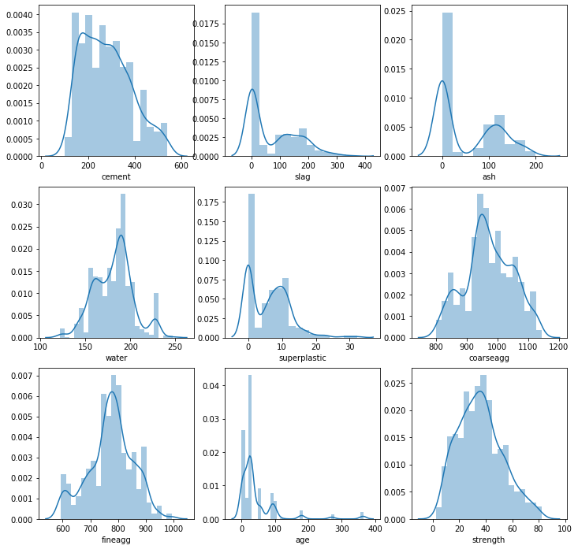

```python
# Plot the distribution for each attribute
plt.figure(figsize=(12, 12))
plt.subplot(3, 3, 1)
sns.distplot(df['cement'])
plt.subplot(3, 3, 2)
sns.distplot(df['slag'])
plt.subplot(3, 3, 3)
sns.distplot(df['ash'])
plt.subplot(3, 3, 4)
sns.distplot(df['water'])
plt.subplot(3, 3, 5)
sns.distplot(df['superplastic'])
plt.subplot(3, 3, 6)
sns.distplot(df['coarseagg'])
plt.subplot(3, 3, 7)
sns.distplot(df['fineagg'])
plt.subplot(3, 3, 8)
sns.distplot(df['age'])
plt.subplot(3, 3, 9)
sns.distplot(df['strength'])
plt.show()
```

"slag", " ash" and "superplastic" have indeed higly unbalanced because of large number of zero values. "age" is also right skewed because of outliers. Multiple modes exist for the last 4 attributes mentionned. Other attributes are pretty well distributed. The target attribute "strenght" is very well balanced and displays a relatively nice normal distribution.

```python
df['ash'].value_counts(normalize=True)
```

```
0.0      0.549515
118.3    0.019417
141.0    0.015534
24.5     0.014563
79.0     0.013592
           ...
119.0    0.000971
134.0    0.000971
95.0     0.000971
130.0    0.000971
129.7    0.000971
Name: ash, Length: 156, dtype: float64
```

55% of 'ash' data are equal to zero. We may want to consider a binary assesment of this attribute : with and without ash.

```python
df['slag'].value_counts(normalize=True)
```

```
0.0      0.457282
189.0    0.029126
106.3    0.019417
24.0     0.013592
20.0     0.011650
           ...
161.0    0.000971
160.5    0.000971
129.0    0.000971
100.6    0.000971
209.0    0.000971
Name: slag, Length: 185, dtype: float64
```

similarly, 46% of 'slag' data are equal to zero. We may want to consider a binary assesment of this attribute : with and without slag.

```python
df['superplastic'].value_counts(normalize=True)
```

```
0.0     0.367961
11.6    0.035922
8.0     0.026214
7.0     0.018447
6.0     0.016505
          ...
2.2     0.000971
11.5    0.000971
6.3     0.000971
10.5    0.000971
9.8     0.000971
Name: superplastic, Length: 111, dtype: float64
```

```python
df['superplastic'].describe()
```

```
count    1030.000000
mean        6.204660
std         5.973841
min         0.000000
25%         0.000000
50%         6.400000
75%        10.200000
max        32.200000
Name: superplastic, dtype: float64
```

37% of the data do not have superplasticizer. We can consider binning this variable. Based on the statistics, 4 categories are proposed: no superplastic, 0<superplastic<6, 6=<superplastic<10, superplastic>=10

```python
df['age'].value_counts(normalize=True)
df['age'].nunique()
```

```
28     0.412621
3      0.130097
7      0.122330
56     0.088350
14     0.060194
90     0.052427
100    0.050485
180    0.025243
91     0.021359
365    0.013592
270    0.012621
360    0.005825
120    0.002913
1      0.001942
Name: age, dtype: float64
```

```
14
```

Only 14 categories of ages are observed. These data can be treated as categorical instead of numerical/continuous values.

```
count    1030.000000
mean       45.662136
std        63.169912
min         1.000000
25%         7.000000
50%        28.000000
75%        56.000000
max       365.000000
Name: age, dtype: float64
```

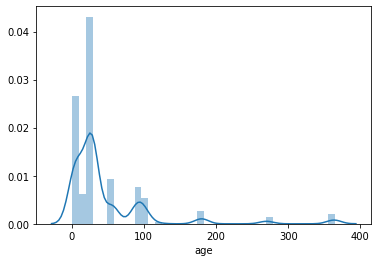

```python
sns.distplot(df['age'],kde='False')
df['age'].describe()
```

Let's take a look now to the outliers by using the boxplots.

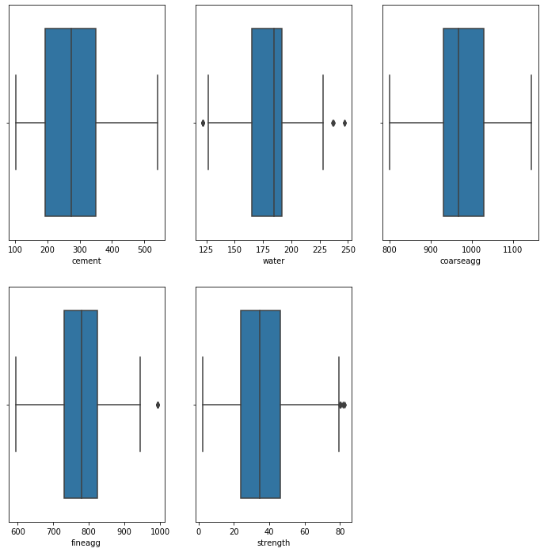

```python
# plot the boxplot to assess the outliers for other attributes.
plt.figure(figsize=(12, 12))
plt.subplot(2, 3, 1)
sns.boxplot(df['cement'])
plt.subplot(2, 3, 2)
sns.boxplot(df['water'])
plt.subplot(2, 3, 3)
sns.boxplot(df['coarseagg'])
plt.subplot(2, 3, 4)
sns.boxplot(df['fineagg'])
plt.subplot(2, 3, 5)
sns.boxplot(df['strength'])
plt.show()
```

A few outliers exist for the variables "water", "fineagg" and 'strenght'.

```
79.77250000000001
```

```
33.4
```

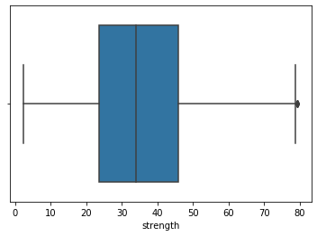

```python
#Replacing outliers with mode value for strenght
outliers_high['strength']
df['strength'].mode()[0]
df.loc[df['strength']>=outliers_high['strength'],'strength']=df['strength'].mode()[0]
sns.boxplot(df['strength'])
```

```
963.575
```

```
594.0
```

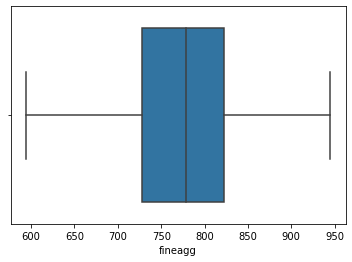

```python
#Replacing outliers with mode value for fineagg
outliers_high['fineagg']
df['fineagg'].mode()[0]
df.loc[df['fineagg']>=outliers_high['fineagg'],'fineagg']=df['fineagg'].mode()[0]
sns.boxplot(df['fineagg'])
```

```
232.64999999999998
```

```
124.25000000000001
```

```
192.0
```

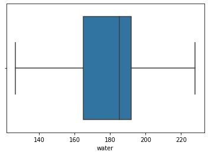

```python
#Replacing outliers with mode value for water
outliers_high['water']
outliers_low['water']
df['water'].mode()[0]
df.loc[df['water']>=outliers_high['water'],'water']=df['water'].mode()[0]
df.loc[df['water']<=outliers_low['water'],'water']=df['water'].mode()[0]
sns.boxplot(df['water'])
```

## 1.2 Bivariate Analysis

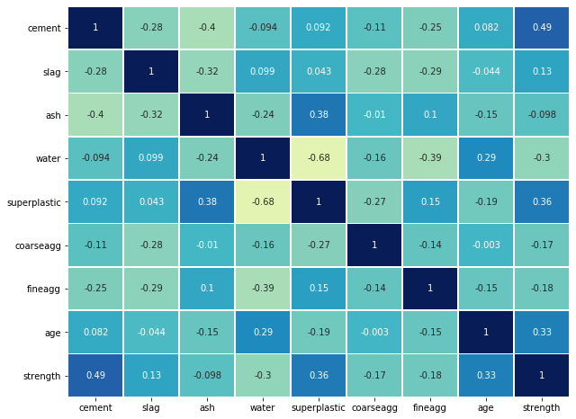

```python
# Check Correlation Matrix
plt.figure(figsize=(10,8))

sns.heatmap(df.corr(),
            annot=True,
            linewidths=.5,
            center=0,
            cbar=False,
            cmap="YlGnBu")

plt.show()
```

We observe the highest correlation values betwwen the variables 'superplastic' and 'water' (-0.68) and betwwen 'cement' and 'strenght' (0.49)

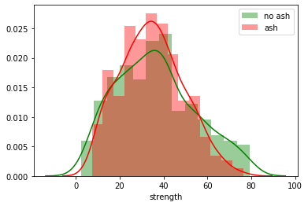

```python
# Analyse the effect of having fly ash on the target variable "strength"
sns.distplot(df[df['ash']==0]['strength'],color='g',label='no ash')
sns.distplot(df[df['ash']>0]['strength'],color='r',label='ash')
plt.legend()
plt.show()
```

The same distribution on the target variable "strenght" is found with or without ash.

```python
# with and without 'ash' statistics
df_ash=df[df['ash']!=0]
df_no_ash=df[df['ash']==0]
df_ash['strength'].describe()
df_no_ash['strength'].describe()
```

```
count    464.000000
mean      34.654461
std       14.234035
min        7.320000
25%       24.212500
50%       33.745000
75%       44.280000
max       76.240000
Name: strength, dtype: float64
```

```
count    566.000000
mean      36.434435
std       18.062267
min        2.330000
25%       22.555000
50%       34.990000
75%       48.625000
max       79.400000
Name: strength, dtype: float64
```

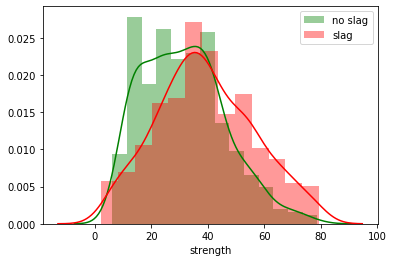

```python
# Analyse the effect of having slag on the target variable "strength"
sns.distplot(df[df['slag']==0]['strength'],color='g',label='no slag')
sns.distplot(df[df['slag']>0]['strength'],color='r',label='slag')
plt.legend()
plt.show()
```

Not having slag in the cement composition tends to decrease the strenght.

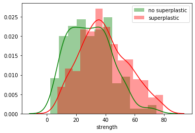

```python
# Analyse the effect of having superplastic on the target variable "strength"
sns.distplot(df[df['superplastic']==0]['strength'],color='g',label='no superplastic')
sns.distplot(df[df['superplastic']>0]['strength'],color='r',label='superplastic')
plt.legend()
plt.show()
```

Not having superplastic in the cement composition tends to decrease the strenght.

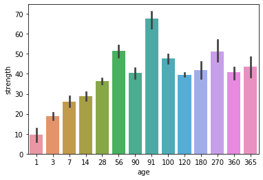

```python
#analyse the variable "age" which has 14 categories
sns.barplot(x='age', y='strength', data=df)
```

It is clear that strength increases with age until ~56 days of ageing then reach a plateau above which the strength is kept constant. We can also obsrev that there is a large varabilty betwwen 90 and 91 days although there is 1 day more only of ageing. We can maybe combine both 90 and 91 days together.

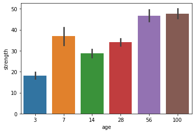

```python
# check the strength vs. age for data with ash
sns.barplot(x='age', y='strength', data=df_ash)
```

fly ash is present mainly for lower age

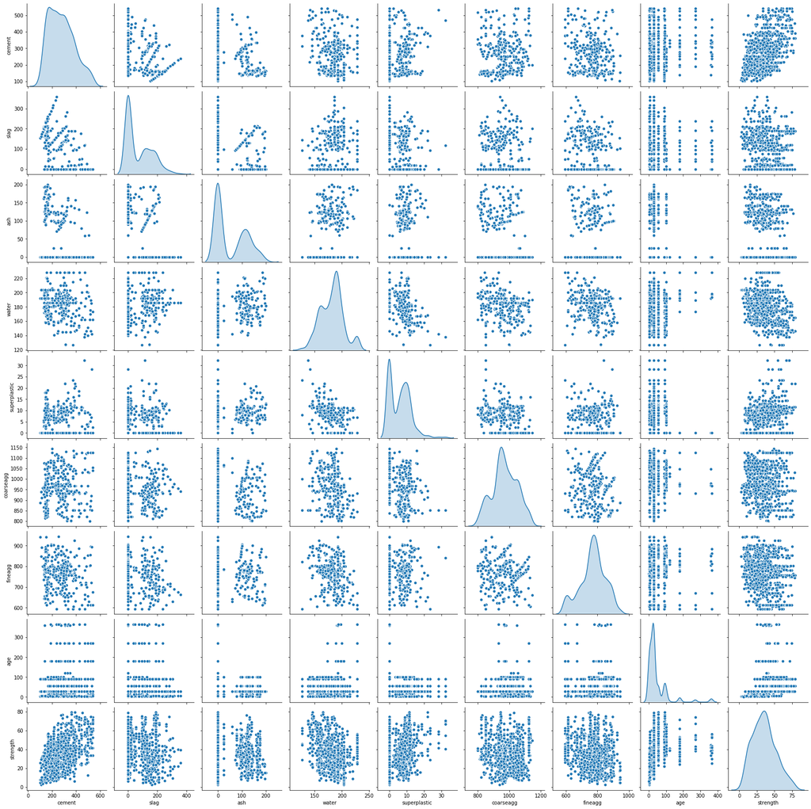

```python
#
sns.pairplot(df, palette="husl", diag_kind = 'kde')
```

## 1.3 Features Engineering

Based on the previous analysis, we observed that categorical output can be created from the current database for the four following variables: age, slag, ash and superplastic. We will create the categories by binning each feature.

```python
# binning superplastic
# 4 categories to be created : no superplastic, 0<superplastic<6, 6=<superplastic<10, superplastic>=10
bin_plastic_edges=[-1,0.1,6.4,10.2,32.2]
bin_plastic_names=['null','low','mid','high']
# defining a new dataframe df_plastic_bin with bining of superplastic
# df_plastic_bin=df_age_bin
df_plastic_bin=df
df_plastic_cut=pd.cut(df['superplastic'],bin_plastic_edges,labels=bin_plastic_names)
df_plastic_cut.head(10)
```

```
0    null
1    high
2     low
3    null
4     mid
5    null
6    null
7     low
8    null
9     mid
Name: superplastic, dtype: category
Categories (4, object): [null < low < mid < high]
```

```python
df_plastic_bin['superplastic']=df_plastic_cut
```

```python
df_plastic_bin.head(10)
```

|  | cement | slag | ash | water | superplastic | coarseagg | fineagg | age | strength |
| --- | --- | --- | --- | --- | --- | --- | --- | --- | --- |
| 0 | 141.3 | 212.0 | 0.0 | 203.5 | null | 971.8 | 748.5 | 28 | 29.89 |
| 1 | 168.9 | 42.2 | 124.3 | 158.3 | high | 1080.8 | 796.2 | 14 | 23.51 |
| 2 | 250.0 | 0.0 | 95.7 | 187.4 | low | 956.9 | 861.2 | 28 | 29.22 |
| 3 | 266.0 | 114.0 | 0.0 | 228.0 | null | 932.0 | 670.0 | 28 | 45.85 |
| 4 | 154.8 | 183.4 | 0.0 | 193.3 | mid | 1047.4 | 696.7 | 28 | 18.29 |
| 5 | 255.0 | 0.0 | 0.0 | 192.0 | null | 889.8 | 945.0 | 90 | 21.86 |
| 6 | 166.8 | 250.2 | 0.0 | 203.5 | null | 975.6 | 692.6 | 7 | 15.75 |
| 7 | 251.4 | 0.0 | 118.3 | 188.5 | low | 1028.4 | 757.7 | 56 | 36.64 |
| 8 | 296.0 | 0.0 | 0.0 | 192.0 | null | 1085.0 | 765.0 | 28 | 21.65 |
| 9 | 155.0 | 184.0 | 143.0 | 194.0 | mid | 880.0 | 699.0 | 28 | 28.99 |

```python
# binning 'ash'
# based on previous statistics, 'ash' can have a binary output : with (>0) and without ash (=0)
# we use the method .where() to replace the non null values by 1
df_plastic_bin['ash'].where(df_plastic_bin['ash']==0, other=1, inplace=True)
df_plastic_bin.head(10)
```

|  | cement | slag | ash | water | superplastic | coarseagg | fineagg | age | strength |
| --- | --- | --- | --- | --- | --- | --- | --- | --- | --- |
| 0 | 141.3 | 212.0 | 0.0 | 203.5 | null | 971.8 | 748.5 | 28 | 29.89 |
| 1 | 168.9 | 42.2 | 1.0 | 158.3 | high | 1080.8 | 796.2 | 14 | 23.51 |
| 2 | 250.0 | 0.0 | 1.0 | 187.4 | low | 956.9 | 861.2 | 28 | 29.22 |
| 3 | 266.0 | 114.0 | 0.0 | 228.0 | null | 932.0 | 670.0 | 28 | 45.85 |
| 4 | 154.8 | 183.4 | 0.0 | 193.3 | mid | 1047.4 | 696.7 | 28 | 18.29 |
| 5 | 255.0 | 0.0 | 0.0 | 192.0 | null | 889.8 | 945.0 | 90 | 21.86 |
| 6 | 166.8 | 250.2 | 0.0 | 203.5 | null | 975.6 | 692.6 | 7 | 15.75 |
| 7 | 251.4 | 0.0 | 1.0 | 188.5 | low | 1028.4 | 757.7 | 56 | 36.64 |
| 8 | 296.0 | 0.0 | 0.0 | 192.0 | null | 1085.0 | 765.0 | 28 | 21.65 |
| 9 | 155.0 | 184.0 | 1.0 | 194.0 | mid | 880.0 | 699.0 | 28 | 28.99 |

```python
# binning 'slag'
# based on statistics, 3 categories can be created : no_slag, low_slag, high_slag
bin_slag_edges=[-1,0.1,90,360]
bin_slag_names=['none','low','high']
# defining a new dataframe
df_slag_bin=df_plastic_bin
df_slag_cut=pd.cut(df['slag'],bin_slag_edges,labels=bin_slag_names)
df_slag_cut.head(10)
```

```
0    high
1     low
2    none
3    high
4    high
5    none
6    high
7    none
8    none
9    high
Name: slag, dtype: category
Categories (3, object): [none < low < high]
```

```python
df_slag_bin['slag']=df_slag_cut
df_slag_bin.head()
```

|  | cement | slag | ash | water | superplastic | coarseagg | fineagg | age | strength |
| --- | --- | --- | --- | --- | --- | --- | --- | --- | --- |
| 0 | 141.3 | high | 0.0 | 203.5 | null | 971.8 | 748.5 | 28 | 29.89 |
| 1 | 168.9 | low | 1.0 | 158.3 | high | 1080.8 | 796.2 | 14 | 23.51 |
| 2 | 250.0 | none | 1.0 | 187.4 | low | 956.9 | 861.2 | 28 | 29.22 |
| 3 | 266.0 | high | 0.0 | 228.0 | null | 932.0 | 670.0 | 28 | 45.85 |
| 4 | 154.8 | high | 0.0 | 193.3 | mid | 1047.4 | 696.7 | 28 | 18.29 |

```python
#redefining a dataframe with transformed/binned data for convenience
df2=df_slag_bin.copy()
df2.head()
df2.info()
```

|  | cement | slag | ash | water | superplastic | coarseagg | fineagg | age | strength |
| --- | --- | --- | --- | --- | --- | --- | --- | --- | --- |
| 0 | 141.3 | high | 0.0 | 203.5 | null | 971.8 | 748.5 | 28 | 29.89 |
| 1 | 168.9 | low | 1.0 | 158.3 | high | 1080.8 | 796.2 | 14 | 23.51 |
| 2 | 250.0 | none | 1.0 | 187.4 | low | 956.9 | 861.2 | 28 | 29.22 |
| 3 | 266.0 | high | 0.0 | 228.0 | null | 932.0 | 670.0 | 28 | 45.85 |
| 4 | 154.8 | high | 0.0 | 193.3 | mid | 1047.4 | 696.7 | 28 | 18.29 |

```
<class 'pandas.core.frame.DataFrame'>
RangeIndex: 1030 entries, 0 to 1029
Data columns (total 9 columns):
 #   Column        Non-Null Count  Dtype
---  ------        --------------  -----
 0   cement        1030 non-null   float64
 1   slag          1030 non-null   category
 2   ash           1030 non-null   float64
 3   water         1030 non-null   float64
 4   superplastic  1030 non-null   category
 5   coarseagg     1030 non-null   float64
 6   fineagg       1030 non-null   float64
 7   age           1030 non-null   int64
 8   strength      1030 non-null   float64
dtypes: category(2), float64(6), int64(1)
memory usage: 58.8 KB
```

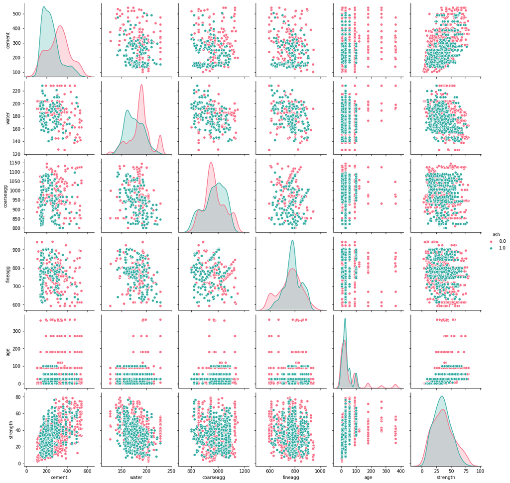

```python
#effect of ash on variables
sns.pairplot(df2, palette="husl", hue='ash',diag_kind = 'kde')
plt.show()
```

[figure not shown]

```python
#effect of slag on variables
sns.pairplot(df2.drop(['ash'], axis=1), palette="husl", hue='slag',diag_kind = 'kde')
plt.show()
```

```python
#Get data model ready
df2['ash'] = df2['ash'].astype('category')#define ash as a categorical variable
df2['age'] = df2['age'].astype('category')#define age as a categorical variable
df2.dtypes
```

[output not shown]

### New feature extraction

We can observe that coarseagg and fineagg are both dealing with the quantity of aggregates, depending on the size (coarse or fine) of the aggregate . The range of density values based of the aggregate size look indeed pretty complementary (between 594kg/m3 and 945kg/m3 for corse aggregate, between 801kg/m3 and 1145kg/m3 for coarse aggregate). Let's see if we can extract a new feature from those variables (the total density of aggregates) and check if we can drop the variables dealing with the size.

```python
#extract statistics for both variables
df2['coarseagg'].describe()
df2['fineagg'].describe()
```

```
count    1030.000000
mean      972.918932
std        77.753954
min       801.000000
25%       932.000000
50%       968.000000
75%      1029.400000
max      1145.000000
Name: coarseagg, dtype: float64
```

```
count    1030.000000
mean      771.645534
std        79.674672
min       594.000000
25%       727.700000
50%       778.900000
75%       822.200000
max       945.000000
Name: fineagg, dtype: float64
```

```python
#concatenate both variables in a new dataframe
df_ag=pd.concat([df2['coarseagg'],df2['fineagg']],axis=1)
#sum both columns to get the total density of aggregates
df_ag['sum']=df_ag['coarseagg']+df_ag['fineagg']
#estimate the percentage of coarse aggregate vs. the total aggregate density
df_ag['percent_coarse']=df_ag['coarseagg']/df_ag['sum']*100
df_ag.head()
```

|  | coarseagg | fineagg | sum | percent_coarse |
| --- | --- | --- | --- | --- |
| 0 | 971.8 | 748.5 | 1720.3 | 56.490147 |
| 1 | 1080.8 | 796.2 | 1877.0 | 57.581247 |
| 2 | 956.9 | 861.2 | 1818.1 | 52.631868 |
| 3 | 932.0 | 670.0 | 1602.0 | 58.177278 |
| 4 | 1047.4 | 696.7 | 1744.1 | 60.053896 |

|  | coarseagg | fineagg | sum | percent_coarse |
| --- | --- | --- | --- | --- |
| count | 1030.000000 | 1030.000000 | 1030.000000 | 1030.000000 |
| mean | 972.918932 | 771.645534 | 1744.564466 | 55.796402 |
| std | 77.753954 | 79.674672 | 103.133129 | 3.466527 |
| min | 801.000000 | 594.000000 | 1446.100000 | 47.930026 |
| 25% | 932.000000 | 727.700000 | 1679.000000 | 52.867286 |
| 50% | 968.000000 | 778.900000 | 1752.450000 | 55.904560 |
| 75% | 1029.400000 | 822.200000 | 1827.400000 | 57.593806 |
| max | 1145.000000 | 945.000000 | 1970.000000 | 65.215891 |

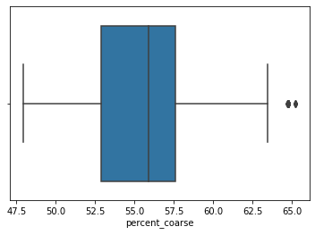

```python
# get statistics and boxplot
df_ag.describe()
sns.boxplot(df_ag['percent_coarse'])
```

Conclusions : there is not a big variation between the percentage of coarse aggregate and fine aggregate. The mean is ~55% with 3.4 standard deviation. We can drop both variables and use the total percentage of aggregate instead.

```python
#creation of a new feature aggreg reprensting the total density of aggregates.
df2['aggreg']=df2['coarseagg']+df2['fineagg']
df2.head()
```

|  | cement | slag | ash | water | superplastic | coarseagg | fineagg | age | strength | aggreg |
| --- | --- | --- | --- | --- | --- | --- | --- | --- | --- | --- |
| 0 | 141.3 | high | 0.0 | 203.5 | null | 971.8 | 748.5 | 28 | 29.89 | 1720.3 |
| 1 | 168.9 | low | 1.0 | 158.3 | high | 1080.8 | 796.2 | 14 | 23.51 | 1877.0 |
| 2 | 250.0 | none | 1.0 | 187.4 | low | 956.9 | 861.2 | 28 | 29.22 | 1818.1 |
| 3 | 266.0 | high | 0.0 | 228.0 | null | 932.0 | 670.0 | 28 | 45.85 | 1602.0 |
| 4 | 154.8 | high | 0.0 | 193.3 | mid | 1047.4 | 696.7 | 28 | 18.29 | 1744.1 |

```python
#drop coarseagg and fineagg
df3=df2.drop(columns=['coarseagg','fineagg'])
df3.head()
```

|  | cement | slag | ash | water | superplastic | age | strength | aggreg |
| --- | --- | --- | --- | --- | --- | --- | --- | --- |
| 0 | 141.3 | high | 0.0 | 203.5 | null | 28 | 29.89 | 1720.3 |
| 1 | 168.9 | low | 1.0 | 158.3 | high | 14 | 23.51 | 1877.0 |
| 2 | 250.0 | none | 1.0 | 187.4 | low | 28 | 29.22 | 1818.1 |
| 3 | 266.0 | high | 0.0 | 228.0 | null | 28 | 45.85 | 1602.0 |
| 4 | 154.8 | high | 0.0 | 193.3 | mid | 28 | 18.29 | 1744.1 |

```python
## Define X (independant) and Y (target) variables
X = df3.drop(['strength'],axis=1)
Y = df3[['strength']] # Target variable
X.head()
Y.head()
```

|  | cement | slag | ash | water | superplastic | age | aggreg |
| --- | --- | --- | --- | --- | --- | --- | --- |
| 0 | 141.3 | high | 0.0 | 203.5 | null | 28 | 1720.3 |
| 1 | 168.9 | low | 1.0 | 158.3 | high | 14 | 1877.0 |
| 2 | 250.0 | none | 1.0 | 187.4 | low | 28 | 1818.1 |
| 3 | 266.0 | high | 0.0 | 228.0 | null | 28 | 1602.0 |
| 4 | 154.8 | high | 0.0 | 193.3 | mid | 28 | 1744.1 |

|  | strength |
| --- | --- |
| 0 | 29.89 |
| 1 | 23.51 |
| 2 | 29.22 |
| 3 | 45.85 |
| 4 | 18.29 |

```python
#Convert categorical variables to dummy variables
X = pd.get_dummies(X,drop_first=True)
X.head()
```

|  | cement | water | aggreg | slag_low | slag_high | ash_1.0 | superplastic_low | superplastic_mid | superplastic_high | age_3 | ... | age_28 | age_56 | age_90 | age_91 | age_100 | age_120 | age_180 | age_270 | age_360 | age_365 |
| --- | --- | --- | --- | --- | --- | --- | --- | --- | --- | --- | --- | --- | --- | --- | --- | --- | --- | --- | --- | --- | --- |
| 0 | 141.3 | 203.5 | 1720.3 | 0 | 1 | 0 | 0 | 0 | 0 | 0 | ... | 1 | 0 | 0 | 0 | 0 | 0 | 0 | 0 | 0 | 0 |
| 1 | 168.9 | 158.3 | 1877.0 | 1 | 0 | 1 | 0 | 0 | 1 | 0 | ... | 0 | 0 | 0 | 0 | 0 | 0 | 0 | 0 | 0 | 0 |
| 2 | 250.0 | 187.4 | 1818.1 | 0 | 0 | 1 | 1 | 0 | 0 | 0 | ... | 1 | 0 | 0 | 0 | 0 | 0 | 0 | 0 | 0 | 0 |
| 3 | 266.0 | 228.0 | 1602.0 | 0 | 1 | 0 | 0 | 0 | 0 | 0 | ... | 1 | 0 | 0 | 0 | 0 | 0 | 0 | 0 | 0 | 0 |
| 4 | 154.8 | 193.3 | 1744.1 | 0 | 1 | 0 | 0 | 1 | 0 | 0 | ... | 1 | 0 | 0 | 0 | 0 | 0 | 0 | 0 | 0 | 0 |

5 rows × 22 columns

```python
#binning target variable
bin_strength_edges=[0,10,20,30,40,50,60,70,80,90]
bin_strenght_names=['10','20','30','40','50','60','70','80','90']
# defining a new dataframe
Y=pd.cut(df['strength'],bin_strength_edges,labels=bin_strenght_names)
Y.head()
```

```
0    30
1    30
2    30
3    50
4    20
Name: strength, dtype: category
Categories (9, object): [10 < 20 < 30 < 40 ... 60 < 70 < 80 < 90]
```

```python
##Split into training and test set
from sklearn.model_selection import train_test_split
X_train, X_test, Y_train, Y_test = train_test_split( X, Y, test_size = 0.3, random_state = 33)
```

```python
#shape of the training and testing independant variables
X_train.shape
X_test.shape
```

```
(721, 22)
```

```
(309, 22)
```

```python
#shape of the training and testing target variables
Y_train.shape
Y_test.shape
```

```
(721,)
```

```
(309,)
```

### Decision on the complexity of the model

We may be prone to "curse of dimensionnality" issues by using simple linear regression models: there are maybe too many dimensions and the algorithm won't be able to learn.  
A too complex model could also lead to overfitting. A linear regression model will be tried first to see its performance for the continuous target variable.

# 2. Create models and tuning it

## 2.1 Linear Regression Model

```python
from sklearn.linear_model import LinearRegression # import the functions
lm=LinearRegression() #call the function
lm.fit(X_train,Y_train)# fit the model
print("Intercept of the linear equation:",lm.intercept_) # see the intercept
print()
print("Co-efficients of the equation are:")
print(lm.coef_)# see the coefficients
print()

#see the error parameters
from sklearn.metrics import mean_absolute_error, mean_squared_error, r2_score

#make prediction
pred=lm.predict(X_test)

print("Mean Absolute Error:",mean_absolute_error(Y_test,pred))
print("RMSE:",mean_squared_error(Y_test,pred)**0.5)
print("R2 Squared testing score:",lm.score(X_test, Y_test))
print("R2 Squared training score:",lm.score(X_train, Y_train))
```

```
LinearRegression(copy_X=True, fit_intercept=True, n_jobs=None, normalize=False)
```

```
Intercept of the linear equation: 39.60285039012328

Co-efficients of the equation are:
[ 8.73460520e-02 -2.23326091e-01 -1.16247723e-02  4.30072821e+00
  1.00004207e+01  9.57380578e-01  2.93995980e+00  3.68172428e+00
  3.16899129e+00  1.27891234e+01  1.86914986e+01  2.79288606e+01
  3.11030043e+01  4.18894718e+01  4.11577479e+01  4.16169695e+01
  4.69330243e+01  4.10417505e+01  3.97683711e+01  5.42520902e+01
  4.39412191e+01  4.31461884e+01]

Mean Absolute Error: 6.637223323835765
RMSE: 8.47554242656207
R2 Squared testing score: 0.7549759438756578
R2 Squared training score: 0.807912435675496
```

The model is slightly overfitted

```python
#perform cross-validation
from sklearn.model_selection import cross_val_score
score_CV_LM = cross_val_score(lm, X, Y, cv = 50).mean()
print(f'Cross validation score of Decision tree = {score_CV_LM}')
```

```
Cross validation score of Decision tree = 0.7527916704448374
```

```python
# storing results in dataframe
ResultsLM = pd.DataFrame({'Method':['Linear Regression'], 'Accur_training': lm.score(X_train,Y_train), 'Accur_testing': lm.score(X_test,Y_test),'CV Score': score_CV_LM})
```

## 2.2 Decision tree model

```python
# invoking the decision tree classifier function.
model_DT = DecisionTreeClassifier()
model_DT.fit(X_train, Y_train)
print("Training accuracy",model_DT.score(X_train,Y_train))  #  training accuracy
print("Testing accuracy",model_DT.score(X_test, Y_test))   #  testing accuracy
```

```
DecisionTreeClassifier(ccp_alpha=0.0, class_weight=None, criterion='gini',
                       max_depth=None, max_features=None, max_leaf_nodes=None,
                       min_impurity_decrease=0.0, min_impurity_split=None,
                       min_samples_leaf=1, min_samples_split=2,
                       min_weight_fraction_leaf=0.0, presort='deprecated',
                       random_state=None, splitter='best')
```

```
Training accuracy 0.9902912621359223
Testing accuracy 0.6407766990291263
```

The model is overfitted

```python
#Print feature importance
pd.Series(model_DT.feature_importances_, X_train.columns ).sort_values(ascending= False)
```

```
cement               0.258791
aggreg               0.212957
water                0.204806
age_28               0.058782
age_7                0.049693
slag_high            0.041095
age_3                0.029895
superplastic_low     0.021216
age_14               0.019954
age_90               0.017850
superplastic_mid     0.016024
superplastic_high    0.015490
ash_1.0              0.012086
age_56               0.011221
slag_low             0.010925
age_100              0.010147
age_180              0.003687
age_91               0.003569
age_360              0.001813
age_120              0.000000
age_270              0.000000
age_365              0.000000
dtype: float64
```

```python
#perform cross-validation
from sklearn.model_selection import cross_val_score
score_CV_DT = cross_val_score(model_DT, X, Y, cv = 50).mean()
print(f'Cross validation score of Decision tree = {score_CV_DT}')
```

```
Cross validation score of Decision tree = 0.664047619047619
```

Cross-validation does not help significantly in increasing the score.

```python
# storing results in dataframe
ResultsDT = pd.DataFrame({'Method':['Decision Tree'], 'Accur_training': model_DT.score(X_train,Y_train), 'Accur_testing': model_DT.score(X_test,Y_test),'CV Score': score_CV_DT})
```

## 2.3 Random Forest

```python
from sklearn.ensemble import RandomForestClassifier
model_rf = RandomForestClassifier(criterion = 'entropy')
model_rf.fit(X_train, Y_train)
# Accuracy
print("Train: %.2f" % model_rf.score(X_train, Y_train))  # performance on train data
print("Test: %.2f" % model_rf.score(X_test, Y_test))  # performance on test data
```

```
RandomForestClassifier(bootstrap=True, ccp_alpha=0.0, class_weight=None,
                       criterion='entropy', max_depth=None, max_features='auto',
                       max_leaf_nodes=None, max_samples=None,
                       min_impurity_decrease=0.0, min_impurity_split=None,
                       min_samples_leaf=1, min_samples_split=2,
                       min_weight_fraction_leaf=0.0, n_estimators=100,
                       n_jobs=None, oob_score=False, random_state=None,
                       verbose=0, warm_start=False)
```

```
Train: 0.99
Test: 0.64
```

```python
#Print feature importance
pd.Series(model_rf.feature_importances_, X_train.columns ).sort_values(ascending= False)
```

```
cement               0.220579
aggreg               0.188111
water                0.173288
age_3                0.071467
age_7                0.042947
age_28               0.040767
slag_high            0.037209
ash_1.0              0.029854
superplastic_high    0.029415
age_56               0.024089
superplastic_mid     0.023518
age_14               0.023046
age_100              0.020057
slag_low             0.017774
superplastic_low     0.015829
age_90               0.014247
age_91               0.009860
age_180              0.006515
age_270              0.003766
age_365              0.003387
age_360              0.003229
age_120              0.001048
dtype: float64
```

```python
#perform cross-validation
from sklearn.model_selection import cross_val_score
score_CV_RF = cross_val_score(model_rf, X, Y, cv = 50).mean()
print(f'Cross validation score of Random Forest = {score_CV_RF}')
```

```
Cross validation score of Random Forest = 0.6731904761904762
```

No big improvement betwwen decision tress and random forest algorithms

```python
# storing results in dataframe
ResultsRF = pd.DataFrame({'Method':['Random Forest'], 'Accur_training': model_rf.score(X_train,Y_train), 'Accur_testing': model_rf.score(X_test,Y_test),'CV Score': score_CV_RF})
```

## 2.4 Adaboost Ensemble Algorithm

```python
from sklearn.ensemble import AdaBoostClassifier
model_ab = AdaBoostClassifier()
model_ab.fit(X_train, Y_train)
# Accuracy
print("Train: %.2f" % model_ab.score(X_train, Y_train))  # performance on train data
print("Test: %.2f" % model_ab.score(X_test, Y_test))  # performance on test data
```

```
AdaBoostClassifier(algorithm='SAMME.R', base_estimator=None, learning_rate=1.0,
                   n_estimators=50, random_state=None)
```

```
Train: 0.33
Test: 0.32
```

The model is better fitted but the performance is bad

```python
#Print feature importance
pd.Series(model_ab.feature_importances_, X_train.columns ).sort_values(ascending= False)
```

```
cement               0.30
water                0.24
aggreg               0.22
age_3                0.08
slag_high            0.06
superplastic_high    0.04
age_14               0.02
age_7                0.02
age_91               0.02
age_56               0.00
age_28               0.00
age_90               0.00
age_360              0.00
age_100              0.00
superplastic_mid     0.00
superplastic_low     0.00
ash_1.0              0.00
age_120              0.00
slag_low             0.00
age_180              0.00
age_270              0.00
age_365              0.00
dtype: float64
```

```python
#perform cross-validation
from sklearn.model_selection import cross_val_score
score_CV_AB = cross_val_score(model_ab, X, Y, cv = 10).mean()
print(f'Cross validation score of Adaboost = {score_CV_AB}')
```

```
Cross validation score of Adaboost = 0.2980582524271844
```

```python
# storing results in dataframe
ResultsAB = pd.DataFrame({'Method':['AdaBoost'], 'Accur_training': model_ab.score(X_train,Y_train), 'Accur_testing': model_ab.score(X_test,Y_test),'CV Score': score_CV_AB})
```

## 2.5 Bagging Classifier Algorithm

```python
from sklearn.ensemble import BaggingClassifier
#model_bg = BaggingClassifier(n_estimators=50, max_samples= .7, bootstrap=True)
model_bg = BaggingClassifier()
model_bg.fit(X_train, Y_train)

# Accuracy
print("Train: %.2f" % model_bg.score(X_train, Y_train))  # performance on train data
print("Test: %.2f" % model_bg.score(X_test, Y_test))  # performance on test data
```

```
BaggingClassifier(base_estimator=None, bootstrap=True, bootstrap_features=False,
                  max_features=1.0, max_samples=1.0, n_estimators=10,
                  n_jobs=None, oob_score=False, random_state=None, verbose=0,
                  warm_start=False)
```

```
Train: 0.98
Test: 0.63
```

```python
#perform cross-validation
from sklearn.model_selection import cross_val_score
score_CV_BG = cross_val_score(model_bg, X, Y, cv = 50).mean()
print(f'Cross validation score of BaggingClassifier = {score_CV_BG}')
```

```
Cross validation score of BaggingClassifier = 0.6544761904761904
```

The model is overfitted

```python
# storing results in dataframe
ResultsBG = pd.DataFrame({'Method':['BaggingClassifier'], 'Accur_training': model_bg.score(X_train,Y_train), 'Accur_testing': model_bg.score(X_test,Y_test),'CV Score': score_CV_BG})
```

## 2.6 Logistic Regression Algorithm

```python
from sklearn.linear_model import LogisticRegression   # importing logistic regression from scikit learn

modelLReg = LogisticRegression(random_state=29,max_iter=100,C=0.03,solver='liblinear')  #assigning a variable for the algorithm

modelLReg.fit(X_train, Y_train) #training of model

Y_predict = modelLReg.predict(X_test)     #model is predicting y values based on test dataset given to the model

print("Training accuracy",modelLReg.score(X_train,Y_train))  #  training accuracy
print()
print("Testing accuracy",modelLReg.score(X_test, Y_test))   #  testing accuracy
```

```
LogisticRegression(C=0.03, class_weight=None, dual=False, fit_intercept=True,
                   intercept_scaling=1, l1_ratio=None, max_iter=100,
                   multi_class='auto', n_jobs=None, penalty='l2',
                   random_state=29, solver='liblinear', tol=0.0001, verbose=0,
                   warm_start=False)
```

```
Training accuracy 0.3828016643550624

Testing accuracy 0.3106796116504854
```

```python
#perform cross-validation
from sklearn.model_selection import cross_val_score
score_CV_LReg = cross_val_score(model, X, Y, cv = 50).mean()
print(f'Cross validation score of Logistics Regression = {score_CV_LReg}')
```

```
Cross validation score of Logistics Regression = 0.3456666666666667
```

```python
# storing results in dataframe
ResultsLReg = pd.DataFrame({'Method':['Logistic Regression'], 'Accur_training': model.score(X_train,Y_train), 'Accur_testing': model.score(X_test,Y_test),'CV Score': score_CV_LReg})
```

```python
# concatenate the dataframes collecting all results for eah model
results = pd.concat([ResultsLM, ResultsDT, ResultsRF, ResultsAB, ResultsBG,ResultsLReg])
results
```

|  | Method | Accur_training | Accur_testing | CV Score |
| --- | --- | --- | --- | --- |
| 0 | Linear Regression | 0.807912 | 0.754976 | 0.752792 |
| 0 | Decision Tree | 0.990291 | 0.640777 | 0.664048 |
| 0 | Random Forest | 0.990291 | 0.644013 | 0.673190 |
| 0 | AdaBoost | 0.334258 | 0.323625 | 0.298058 |
| 0 | BaggingClassifier | 0.976422 | 0.627832 | 0.654476 |
| 0 | Logistic Regression | 0.382802 | 0.310680 | 0.345667 |

## 2.6 Hyperparameters Tuning

The random forest and regression algorithms are selected to tune the models.

### Random Forest Model Tuning

```python
from scipy.stats import randint as sp_randint
from sklearn.model_selection import GridSearchCV
from sklearn.model_selection import RandomizedSearchCV
# specify parameters and distributions to sample from
param_dist = {"n_estimators": sp_randint(50, 500),
              "max_depth": sp_randint(1, 20),
              "max_features": sp_randint(1, 22),
              "bootstrap": [True, False],
              "criterion": ["gini", "entropy"]}
```

```python
# run randomized search first
samples = 30  # number of random samples
randomCV = RandomizedSearchCV(model_rf, param_distributions=param_dist, n_iter=samples)
```

```python
randomCV.fit(X, Y)
print(randomCV.best_params_)
```

```
RandomizedSearchCV(cv=None, error_score=nan,
                   estimator=RandomForestClassifier(bootstrap=True,
                                                    ccp_alpha=0.0,
                                                    class_weight=None,
                                                    criterion='entropy',
                                                    max_depth=None,
                                                    max_features='auto',
                                                    max_leaf_nodes=None,
                                                    max_samples=None,
                                                    min_impurity_decrease=0.0,
                                                    min_impurity_split=None,
                                                    min_samples_leaf=1,
                                                    min_samples_split=2,
                                                    min_weight_fraction_leaf=0.0,
                                                    n_estimators=100,...
                                        'max_depth': <scipy.stats._distn_infrastructure.rv_frozen object at 0x0000016F53E73A08>,
                                        'max_features': <scipy.stats._distn_infrastructure.rv_frozen object at 0x0000016F53E73D08>,
                                        'n_estimators': <scipy.stats._distn_infrastructure.rv_frozen object at 0x0000016F53E63648>},
                   pre_dispatch='2*n_jobs', random_state=None, refit=True,
                   return_train_score=False, scoring=None, verbose=0)
```

```
{'bootstrap': False, 'criterion': 'entropy', 'max_depth': 11, 'max_features': 9, 'n_estimators': 319}
```

```python
model_rf2 = RandomForestClassifier(bootstrap='True', criterion= 'entropy', max_depth= 15, max_features= 10,n_estimators=150)
model_rf2.fit(X_train, Y_train)
# Accuracy
print("Train: %.2f" % model_rf2.score(X_train, Y_train))  # performance on train data
print("Test: %.2f" % model_rf2.score(X_test, Y_test))  # performance on test data
```

```
RandomForestClassifier(bootstrap='True', ccp_alpha=0.0, class_weight=None,
                       criterion='entropy', max_depth=15, max_features=10,
                       max_leaf_nodes=None, max_samples=None,
                       min_impurity_decrease=0.0, min_impurity_split=None,
                       min_samples_leaf=1, min_samples_split=2,
                       min_weight_fraction_leaf=0.0, n_estimators=150,
                       n_jobs=None, oob_score=False, random_state=None,
                       verbose=0, warm_start=False)
```

```
Train: 0.99
Test: 0.67
```

```python
#Parameter Tuning Using GridDSearch
from sklearn.model_selection import GridSearchCV
parameters_GS = {'bootstrap': [True],
              'criterion': ['entropy'],
 'max_depth': [9, 12, 15, 17, 20],
 'max_features': [8, 10, 12],
 'n_estimators': [130,140,150,160,170]}
```

```python
GridSearchCV = GridSearchCV(model_rf, parameters_GS, cv = 5, verbose = 2, n_jobs= 4)
GridSearchCV.fit(X, Y)

GridSearchCV.best_params_
```

```
Fitting 5 folds for each of 75 candidates, totalling 375 fits
```

```
[Parallel(n_jobs=4)]: Using backend LokyBackend with 4 concurrent workers.
[Parallel(n_jobs=4)]: Done  33 tasks      | elapsed:    3.5s
[Parallel(n_jobs=4)]: Done 154 tasks      | elapsed:   13.8s
[Parallel(n_jobs=4)]: Done 357 tasks      | elapsed:   32.2s
[Parallel(n_jobs=4)]: Done 375 out of 375 | elapsed:   33.9s finished
```

```
GridSearchCV(cv=5, error_score=nan,
             estimator=RandomForestClassifier(bootstrap=True, ccp_alpha=0.0,
                                              class_weight=None,
                                              criterion='entropy',
                                              max_depth=None,
                                              max_features='auto',
                                              max_leaf_nodes=None,
                                              max_samples=None,
                                              min_impurity_decrease=0.0,
                                              min_impurity_split=None,
                                              min_samples_leaf=1,
                                              min_samples_split=2,
                                              min_weight_fraction_leaf=0.0,
                                              n_estimators=100, n_jobs=None,
                                              oob_score=False,
                                              random_state=None, verbose=0,
                                              warm_start=False),
             iid='deprecated', n_jobs=4,
             param_grid={'bootstrap': [True], 'criterion': ['entropy'],
                         'max_depth': [9, 12, 15, 17, 20],
                         'max_features': [8, 10, 12],
                         'n_estimators': [130, 140, 150, 160, 170]},
             pre_dispatch='2*n_jobs', refit=True, return_train_score=False,
             scoring=None, verbose=2)
```

```
{'bootstrap': True,
 'criterion': 'entropy',
 'max_depth': 20,
 'max_features': 12,
 'n_estimators': 150}
```

```python
model_rf3 = RandomForestClassifier(bootstrap='True', criterion= 'entropy', max_depth= 12, max_features= 12,n_estimators=150)
model_rf3.fit(X_train, Y_train)
# Accuracy
print("Train: %.2f" % model_rf3.score(X_train, Y_train))  # performance on train data
print("Test: %.2f" % model_rf3.score(X_test, Y_test))  # performance on test data
```

```
RandomForestClassifier(bootstrap='True', ccp_alpha=0.0, class_weight=None,
                       criterion='entropy', max_depth=12, max_features=12,
                       max_leaf_nodes=None, max_samples=None,
                       min_impurity_decrease=0.0, min_impurity_split=None,
                       min_samples_leaf=1, min_samples_split=2,
                       min_weight_fraction_leaf=0.0, n_estimators=150,
                       n_jobs=None, oob_score=False, random_state=None,
                       verbose=0, warm_start=False)
```

```
Train: 0.99
Test: 0.67
```

```python
#perform cross-validation
from sklearn.model_selection import cross_val_score
score_CV_RF2 = cross_val_score(model_rf3, X, Y, cv = 50).mean()
print(f'Cross validation score of Random Forest Tuned = {score_CV_RF2}')
```

```
Cross validation score of Random Forest Tuned = 0.6826666666666665
```

```python
# storing results in dataframe
ResultsRF2 = pd.DataFrame({'Method':['Random Forest Tuned'], 'Accur_training': model_rf3.score(X_train,Y_train), 'Accur_testing': model_rf3.score(X_test,Y_test),'CV Score': score_CV_RF2})
```

### Linear Regression Model Tuning

```python
param_LR = {"fit_intercept": ['False','True'],
              "normalize": ['False','True'],
              "copy_X": ['False','True']}
```

```python
#use of gridSearch
from sklearn.model_selection import GridSearchCV
GridSearchCV_LR = GridSearchCV(lm, param_LR, cv = 5, verbose = 2, n_jobs= 4)
GridSearchCV_LR.fit(X, Y)

GridSearchCV_LR.best_params_
```

```
Fitting 5 folds for each of 8 candidates, totalling 40 fits
```

```
[Parallel(n_jobs=4)]: Using backend LokyBackend with 4 concurrent workers.
[Parallel(n_jobs=4)]: Done  40 out of  40 | elapsed:    1.1s finished
```

```
GridSearchCV(cv=5, error_score=nan,
             estimator=LinearRegression(copy_X=True, fit_intercept=True,
                                        n_jobs=None, normalize=False),
             iid='deprecated', n_jobs=4,
             param_grid={'copy_X': ['False', 'True'],
                         'fit_intercept': ['False', 'True'],
                         'normalize': ['False', 'True']},
             pre_dispatch='2*n_jobs', refit=True, return_train_score=False,
             scoring=None, verbose=2)
```

```
{'copy_X': 'False', 'fit_intercept': 'False', 'normalize': 'False'}
```

```python
from sklearn.linear_model import LinearRegression # import the functions
lm2=LinearRegression(copy_X="False",fit_intercept='False',normalize='False') #call the function
lm2.fit(X_train,Y_train)# fit the model
print("Intercept of the linear equation:",lm.intercept_) # see the intercept
print()
print("Co-efficients of the equation are:")
print(lm.coef_)# see the coefficients
print()

#see the error parameters
from sklearn.metrics import mean_absolute_error, mean_squared_error, r2_score

#make prediction
pred=lm2.predict(X_test)

print("Mean Absolute Error:",mean_absolute_error(Y_test,pred))
print("RMSE:",mean_squared_error(Y_test,pred)**0.5)
print("R2 Squared testing score:",lm2.score(X_test, Y_test))
print("R2 Squared training score:",lm2.score(X_train, Y_train))
```

```
LinearRegression(copy_X='False', fit_intercept='False', n_jobs=None,
                 normalize='False')
```

```
Intercept of the linear equation: 39.60285039012328

Co-efficients of the equation are:
[ 8.73460520e-02 -2.23326091e-01 -1.16247723e-02  4.30072821e+00
  1.00004207e+01  9.57380578e-01  2.93995980e+00  3.68172428e+00
  3.16899129e+00  1.27891234e+01  1.86914986e+01  2.79288606e+01
  3.11030043e+01  4.18894718e+01  4.11577479e+01  4.16169695e+01
  4.69330243e+01  4.10417505e+01  3.97683711e+01  5.42520902e+01
  4.39412191e+01  4.31461884e+01]

Mean Absolute Error: 6.637223323835762
RMSE: 8.475542426562068
R2 Squared testing score: 0.7549759438756579
R2 Squared training score: 0.807912435675496
```

```python
#perform cross-validation
from sklearn.model_selection import cross_val_score
score_CV_LM2 = cross_val_score(lm2, X, Y, cv = 10).mean()
print(f'Cross validation score of Linear Regression Tuned = {score_CV_LM2}')
```

```
Cross validation score of Linear Regression Tuned = 0.7748411756569318
```

```python
# storing results in dataframe
ResultsLM2 = pd.DataFrame({'Method':['Linear Regression Tuned'], 'Accur_training': lm2.score(X_train,Y_train), 'Accur_testing': lm2.score(X_test,Y_test),'CV Score': score_CV_LM2})
```

### Logistic Regression Model Tuning

```python
param_LReg = {"penalty": ['l1','l2','elasticnet'],
              "C": [0.005,0.05,0.1],
              "solver": ['lbfgs','liblinear','sag'], 'max_iter':[200,250,300,500],'multi_class':['auto', 'ovr', 'multinomial']}
```

```python
#use of gridSearch
from sklearn.model_selection import GridSearchCV
GridSearchCV_LReg = GridSearchCV(modelLReg, param_LReg, cv = 5, verbose = 2, n_jobs= 4)
GridSearchCV_LReg.fit(X, Y)

GridSearchCV_LReg.best_params_
```

```
Fitting 5 folds for each of 324 candidates, totalling 1620 fits
```

```
[Parallel(n_jobs=4)]: Using backend LokyBackend with 4 concurrent workers.
[Parallel(n_jobs=4)]: Done 116 tasks      | elapsed:    1.2s
[Parallel(n_jobs=4)]: Done 1080 tasks      | elapsed:   16.7s
[Parallel(n_jobs=4)]: Done 1620 out of 1620 | elapsed:   27.8s finished
```

```
GridSearchCV(cv=5, error_score=nan,
             estimator=LogisticRegression(C=0.03, class_weight=None, dual=False,
                                          fit_intercept=True,
                                          intercept_scaling=1, l1_ratio=None,
                                          max_iter=100, multi_class='auto',
                                          n_jobs=None, penalty='l2',
                                          random_state=29, solver='liblinear',
                                          tol=0.0001, verbose=0,
                                          warm_start=False),
             iid='deprecated', n_jobs=4,
             param_grid={'C': [0.005, 0.05, 0.1],
                         'max_iter': [200, 250, 300, 500],
                         'multi_class': ['auto', 'ovr', 'multinomial'],
                         'penalty': ['l1', 'l2', 'elasticnet'],
                         'solver': ['lbfgs', 'liblinear', 'sag']},
             pre_dispatch='2*n_jobs', refit=True, return_train_score=False,
             scoring=None, verbose=2)
```

```
{'C': 0.1,
 'max_iter': 200,
 'multi_class': 'ovr',
 'penalty': 'l2',
 'solver': 'lbfgs'}
```

```python
modelLReg2 = LogisticRegression(random_state=29,max_iter=200,C=0.1,solver='lbfgs', penalty='l2')  #assigning a variable for the algorithm

modelLReg2.fit(X_train, Y_train) #training of model

Y_predict = modelLReg2.predict(X_test)     #model is predicting y values based on test dataset given to the model

print("Training accuracy",modelLReg2.score(X_train,Y_train))  #  training accuracy
print()
print("Testing accuracy",modelLReg2.score(X_test, Y_test))   #  testing accuracy
```

```
LogisticRegression(C=0.1, class_weight=None, dual=False, fit_intercept=True,
                   intercept_scaling=1, l1_ratio=None, max_iter=200,
                   multi_class='auto', n_jobs=None, penalty='l2',
                   random_state=29, solver='lbfgs', tol=0.0001, verbose=0,
                   warm_start=False)
```

```
Training accuracy 0.27600554785020803

Testing accuracy 0.2783171521035599
```

```python
#perform cross-validation
from sklearn.model_selection import cross_val_score
score_CV_LReg2 = cross_val_score(modelLReg2, X, Y, cv = 10).mean()
print(f'Cross validation score of Logistic Regression Tuned = {score_CV_LReg2}')
```

```
Cross validation score of Logistic Regression Tuned = 0.2543689320388349
```

```python
# storing results in dataframe
ResultsLReg2 = pd.DataFrame({'Method':['Logistic Regression Tuned'], 'Accur_training': modelLReg2.score(X_train,Y_train), 'Accur_testing': modelLReg2.score(X_test,Y_test),'CV Score': score_CV_LReg2})
```

### Comparing tuned models and initial models

```python
# concatenate the dataframes collecting all results for eah model
results_tuned = pd.concat([results, ResultsRF2, ResultsLM2,ResultsLReg2])
results_tuned
```

|  | Method | Accur_training | Accur_testing | CV Score |
| --- | --- | --- | --- | --- |
| 0 | Linear Regression | 0.807912 | 0.754976 | 0.752792 |
| 0 | Decision Tree | 0.990291 | 0.640777 | 0.664048 |
| 0 | Random Forest | 0.990291 | 0.644013 | 0.673190 |
| 0 | AdaBoost | 0.334258 | 0.323625 | 0.298058 |
| 0 | BaggingClassifier | 0.976422 | 0.627832 | 0.654476 |
| 0 | Logistic Regression | 0.382802 | 0.310680 | 0.345667 |
| 0 | Random Forest Tuned | 0.987517 | 0.666667 | 0.682667 |
| 0 | Linear Regression Tuned | 0.807912 | 0.754976 | 0.774841 |
| 0 | Logistic Regression Tuned | 0.276006 | 0.278317 | 0.254369 |

Tuning a few hyperparameters did not improve significantly the model score. A simple linear regression model looks to be the most suitable.